# STATISTICAL COMPUTING PROJECT

Adem VAROL - 200709078 / Wael KABOUK - 190709723

08 Haziran 2022

## 1. (3p) Data:

Please find your original data set or data sets; and describe your data in the first step.

The real data of OAL and YEAL schools were used in order to examine the success of the two schools according to the GPA of the students and the status of their families (for example, parents divorced, mother died, father died, etc.).

GitHub Link: https://github.com/200709078/SC_PROJECT

## 2. (3p) Exploratory and descriptive data analysis:

Use “Exploratory and descriptive data analysis”. Talk about your categorical and quantitative data or your ordinal variables etc. Write down your comments.

```r
## install.packages("readxl")
library("readxl")
dFile <- read_excel("SC_DATA.xls")
names(dFile)
```

```
##  [1] "SCHOOL"          "CLASS"           "NUMBER"          "FULLNAME"
##  [5] "GENDER"          "STAY"            "GPA"             "MAF_PS"
##  [9] "CHILD_1"         "CHILDREN_3"      "MAF_DIV"         "MOTHER_DIED"
## [13] "FATHER_DIED"     "FAMILY_PATIENT"  "STUDENT_PATIENT"
```

ORDINAL VARIABLE:  
NUMBER (1470, 1471, …)  
FULLNAME (Adem VAROL, … , Wael KABOUK)

CATEGORICAL VARIABLES:  
SCHOOL (OAL, YEAL)  
CLASS (9A, 9B, 9C, …)  
GENDER (1 : Male, 0 : Female)  
STAY (1 : Stay in the town, 0 : Stay in the village)  
MAF_PS (Mother and father are primary school graduates, 1 : Yes, 0 : No)  
CHILD_1 (1 : One Kid, 0 : Two Kids)  
CHILDREN_3 (1 : Three Kids, 0 : More than three children)  
MAF_DIV (Mother and father divided, 1 : Yes, 0 : No)  
MOTHER_DIED (1 : Yes, 0 : No)  
FATHER_DIED (1 : Yes, 0 : No)  
FAMILY_PATIENT (Has a family member who is sick, 1 : Yes, 0 : No)  
STUDENT_PATIENT (The student has a sick, 1 : Yes, 0 : No)

QUANTITATIVE VARIABLE:  
GPA (Grade point average)

```r
summary(dFile$GPA)
```

```
##    Min. 1st Qu.  Median    Mean 3rd Qu.    Max.
##    0.00   42.52   57.51   57.61   73.18   99.03
```

```r
## head(dFile)
```

## 3. (3p) Data Visualization:

Use at least 4 different “data visualization techniques” and talk about your data further (distribution, outliers, variability, etc). Use at least 2 of the visualizations to compare two groups (like female/male; smoker/non-smoker etc).

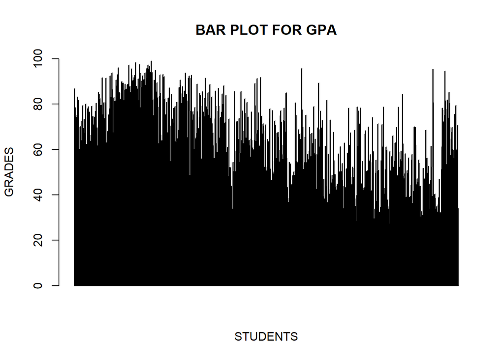

```r
library(MASS)
library(ggplot2)

barplot(dFile$GPA, main = 'BAR PLOT FOR GPA', xlab = 'STUDENTS', ylab = "GRADES", horiz = FALSE, ylim = c(0,100))
```

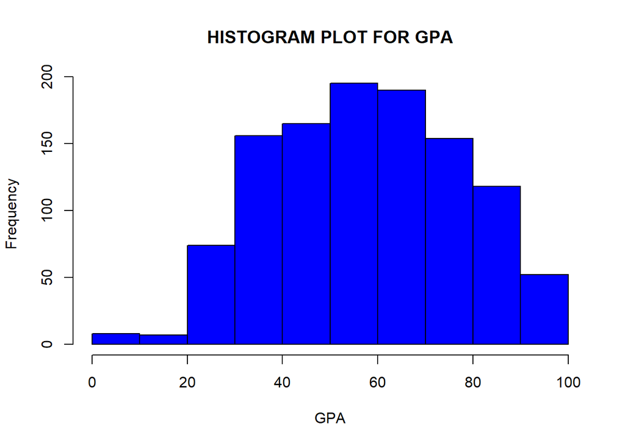

```r
hist(dFile$GPA, main ="HISTOGRAM PLOT FOR GPA", xlab ="GPA", xlim = c(0, 100), col ="blue", freq = TRUE, breaks = 10)
```

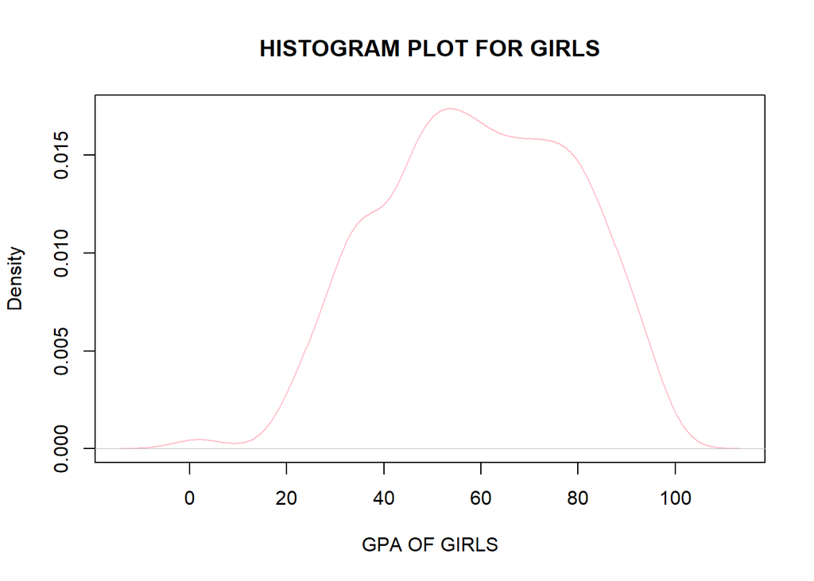

```r
plot(density(subset(dFile, GENDER=="0")$GPA), xlab = "GPA OF GIRLS", main = "HISTOGRAM PLOT FOR GIRLS",col="pink")
```

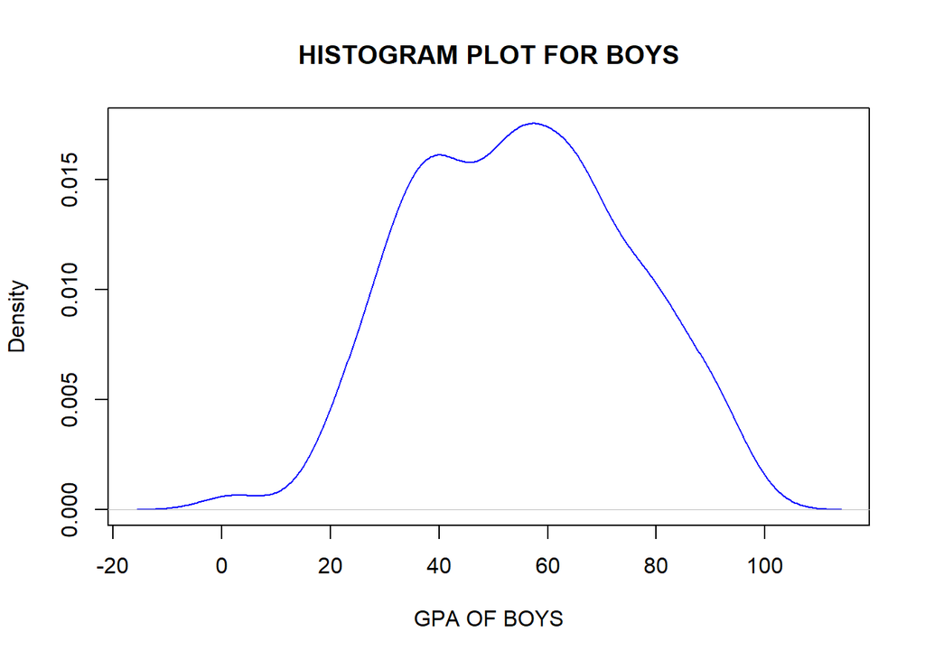

```r
plot(density(subset(dFile, GENDER=="1")$GPA), xlab = "GPA OF BOYS", main = "HISTOGRAM PLOT FOR BOYS",col="blue")
```

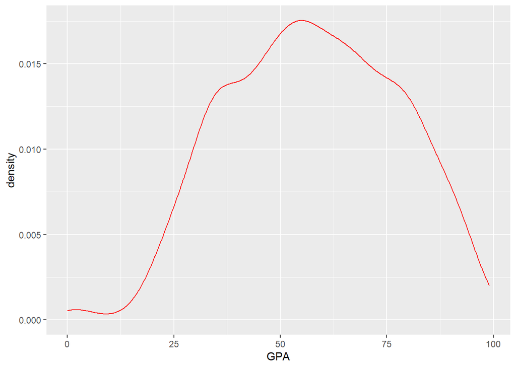

```r
ggplot(dFile, aes(x=GPA)) + geom_density(col="red")
```

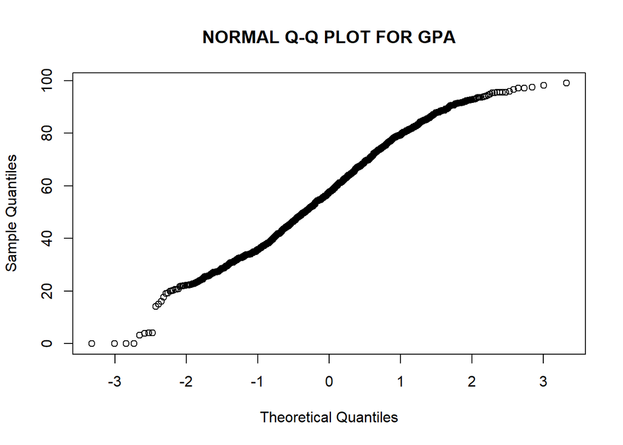

```r
qqnorm(dFile$GPA, pch = 1, frame = TRUE, main ="NORMAL Q-Q PLOT FOR GPA")
```

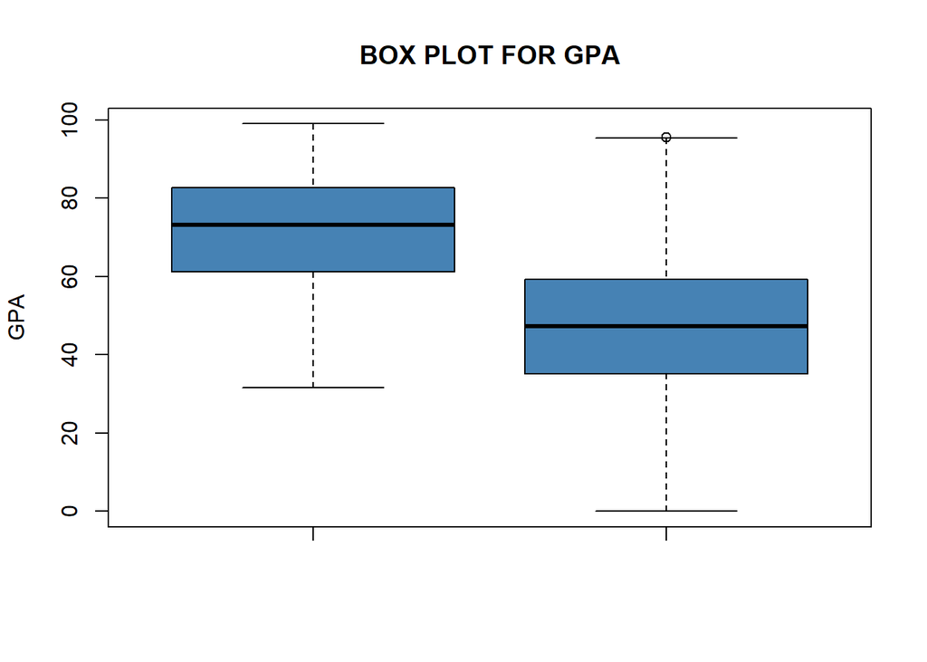

```r
# qqline(dFile$GPA, col = "steelblue", lwd = 2)

dataOAL <- subset(dFile, SCHOOL=="OAL")
dataYEAL <- subset(dFile, SCHOOL=="YEAL")
boxplot(main="BOX PLOT FOR GPA", dataOAL$GPA, dataYEAL$GPA, ylab ="GPA", col="steelblue")
```

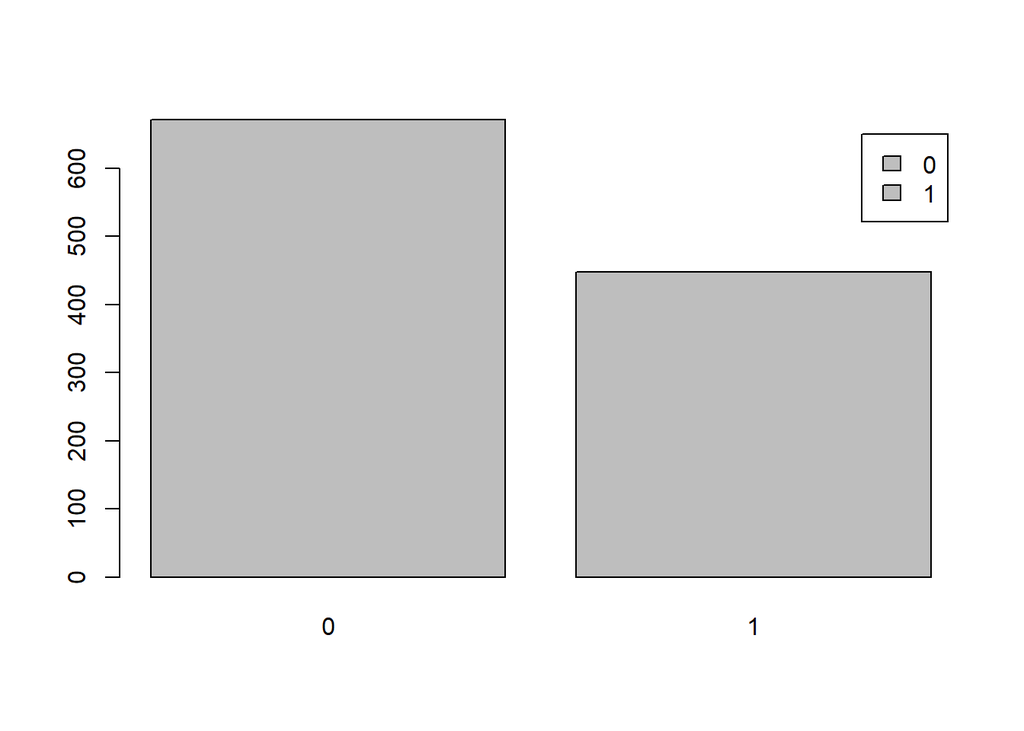

```r
TABL=table(dFile$GENDER)
barplot(TABL,beside = T, legend = T)
```

## 4. (3p) Central Limit Theorem:

Choose one of your variables. Write down your own function which proves the central limit theorem (CLT): show that whatever the distribution is, the sampling data will be distributed normally. (have a look at the example in Statistics_Lecture_5, page9)

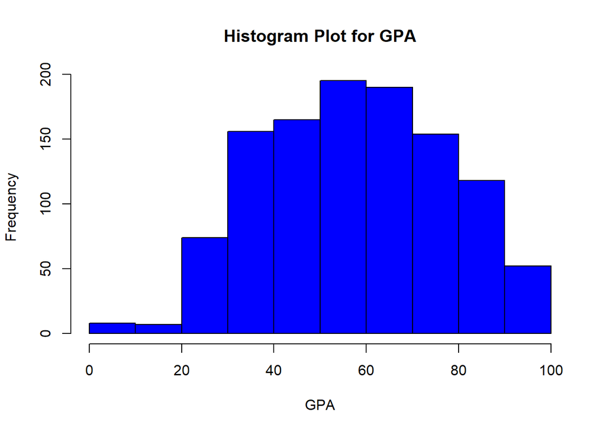

```r
library(shiny)

hist(dFile$GPA, main ="Histogram Plot for GPA", xlab ="GPA", xlim = c(0, 100),
    col ="blue", freq = TRUE, breaks = 10)
```

```r
shapiro.test(dFile$GPA)
```

```
##
##  Shapiro-Wilk normality test
##
## data:  dFile$GPA
## W = 0.98619, p-value = 8.546e-09
```

```r
#H0: Data is Normally Distributed
#H1: Data is not Normally Distributed    alpha=0.05

#If p ≤ 0.05: then the null hypothesis can be rejected
#If p > 0.05: then the null hypothesis cannot be rejected
# So p is less than 0.05 our data is not normally distributed.
```

## 5. (3p) Confidence Intervals:

Build 2 confidence intervals and make “clear comments” about your findings.

```r
#t-test
gpa.mean <- mean(dFile$GPA)
gpa.sd <- sd(dFile$GPA)
gpa.se <- gpa.sd/sqrt(length(dFile))

t.test(dFile$GPA,mu=2000)
```

```
##
##  One Sample t-test
##
## data:  dFile$GPA
## t = -3296.4, df = 1118, p-value < 2.2e-16
## alternative hypothesis: true mean is not equal to 2000
## 95 percent confidence interval:
##  56.45727 58.76954
## sample estimates:
## mean of x
##   57.6134
```

```r
#Confidence interval
t.score1 <-  qt(p=0.05, df=80,lower.tail=F)

error <- t.score1 * gpa.se
lower.bound <- gpa.mean  - error
upper.bound <- gpa.mean  + error
sprintf('%f < x < %f',lower.bound, upper.bound)
```

```
## [1] "49.144129 < x < 66.082681"
```

```r
# print(c(lower.bound, upper.bound))

dataA <- subset(dFile, lower.bound < GPA & GPA<upper.bound)

#1 — Hypothesis for first Fisher’s Exact Test (Alternative Two Sided):
#Ho: The odds ratio is equal to 1
#Ha: The odds ratio is not equal to 1
#2 — Hypothesis for first Fisher’s Exact Test (Alternative Less):
#Ho: The odds ratio is equal to or greater than 1
#Ha: The odds ratio is less than 1
#3 — Hypothesis for first Fisher’s Exact Test (Alternative Greater):
#Ho: The odds ratio is equal to or less than 1
#Ha: The odds ratio is greater than 1
```

## 6. (3p) Transformation:

Try to make one transformation (log transformation, Box-Cok transformation, etc) for one of your quantitative variables, which is not normally distributed; but will be normal or more normal, after the transformation.

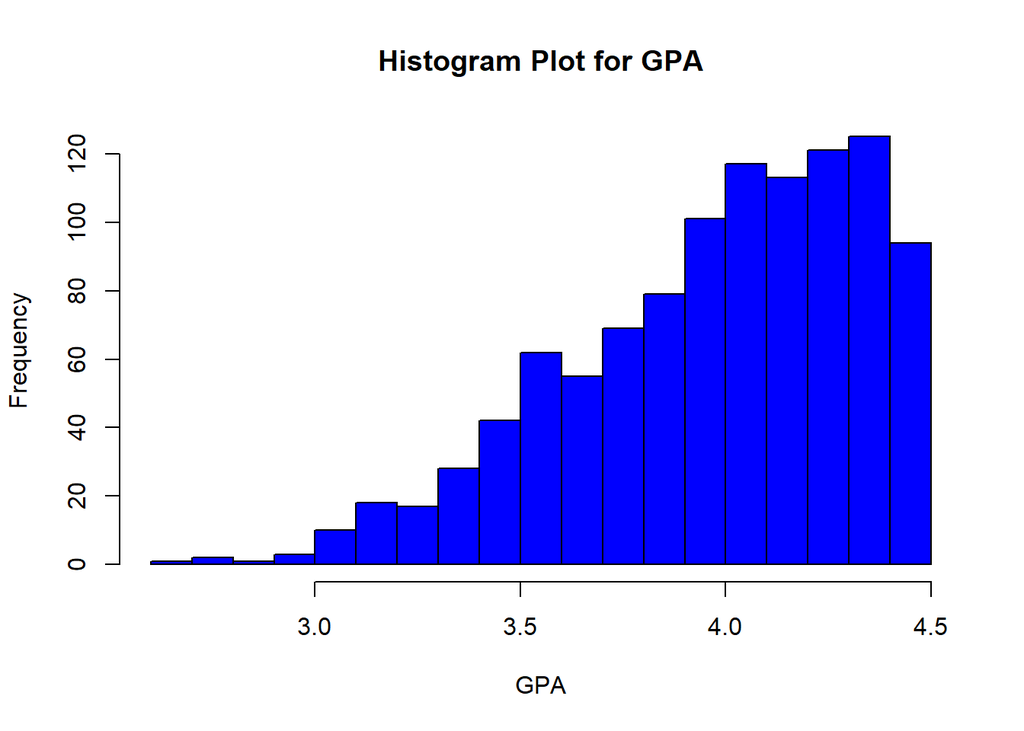

```r
withoutoutliers <- subset(dFile, 10<GPA & GPA<90)

#log transform
dFile.log <- transform(withoutoutliers, GPA.log=log(GPA))

#histograms
hist(dFile.log$GPA.log, col="blue",xlab = "GPA" ,main = "Histogram Plot for GPA",breaks = 15)
```

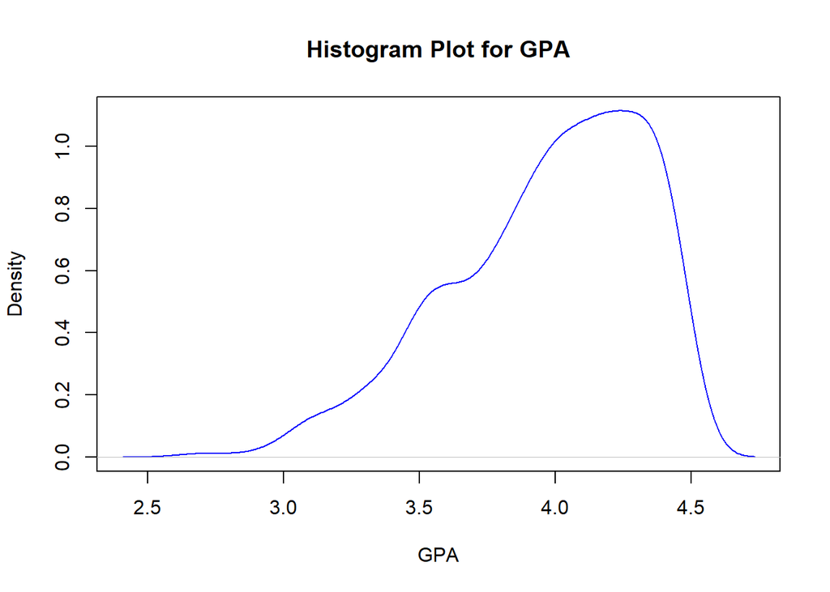

```r
#density plots with basic R
d.GPA <- density(dFile.log$GPA.log)
plot(d.GPA, xlab = "GPA",main = "Histogram Plot for GPA",col="blue")
```

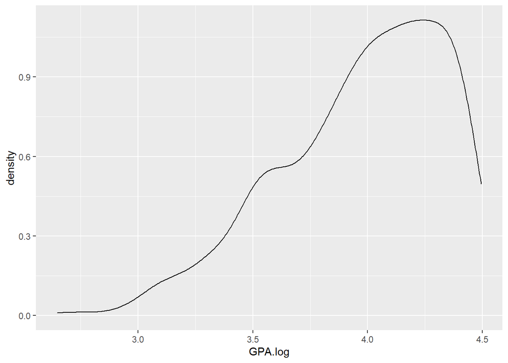

```r
#density plots with ggplot2
ggplot(dFile.log, aes(x=GPA.log)) + geom_density()
```

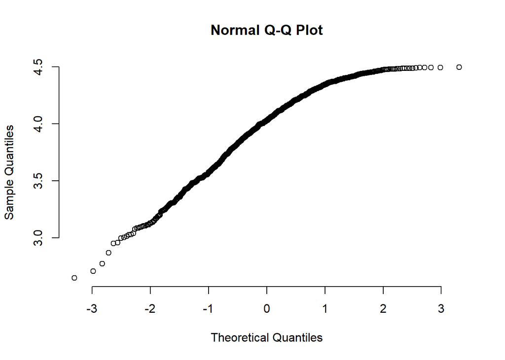

```r
#qqplots
qqnorm(dFile.log$GPA.log, pch = 1, frame = FALSE)
```

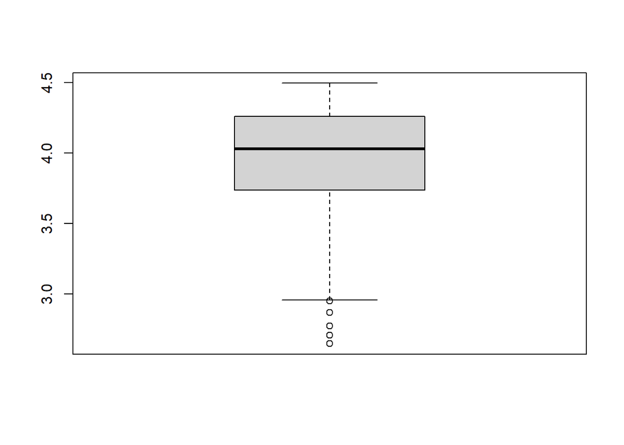

```r
#qqline(dFile.log$GPA.log, col = "steelblue", lwd = 2,xlab = "GPA")

#boxplots
boxplot(dFile.log$GPA.log)
```

## 7. (2p every item) Single t-test (Welch t-test or Wilcoxon rank-sum test)

Implement a single t-test for one of your “normally or not-normally distributed” variable:

1. Aim In words, what is your objective here?

**Checking whether the average GPA of the whole students is equal or greater than 70**

2. Hypothesis and level of significance: Write your hypothesis in scientific form and determine the level of significance.

**H0: mu=70, H1: mu < 70, alpha = 0.05**

3. Assumption Check: Check the required assumptions and “comment on each of them is a must!”.

**Assuming the data is not normally distributed, equal variance**

4. Indicate “which test you choose” “for what reason”

**Single t-test,assumptions above**

5. Result: Give the output of the test and write down the result (ex: since p value is less than alpha, I reject the null hypothesis).

**Since p-value is less than alpha we reject the null hypothesis**

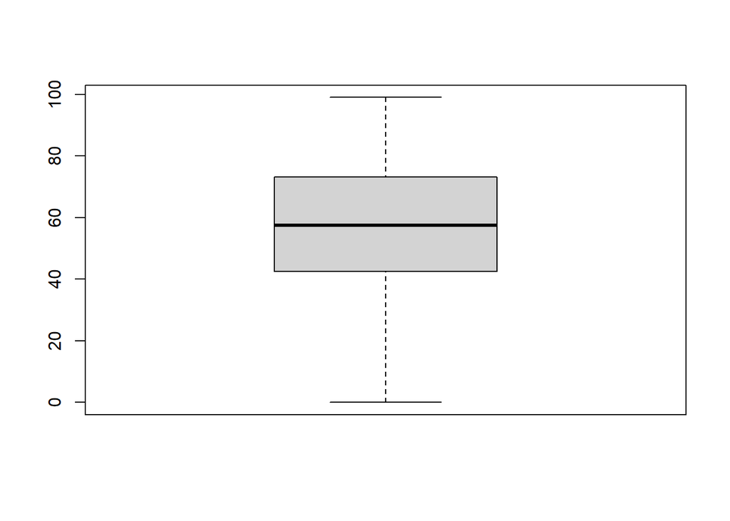

```r
boxplot(dFile$GPA)
```

```r
TEST<- t.test(dFile$GPA, mu=70, alt = "less", conf = 0.95)
TEST$null.value
```

```
## mean
##   70
```

```r
TEST$alternative
```

```
## [1] "less"
```

```r
TEST$conf.int
```

```
## [1]     -Inf 58.58342
## attr(,"conf.level")
## [1] 0.95
```

```r
TEST$p.value
```

```
## [1] 3.074219e-83
```

6. Conclusion: You got your result in item e. Write down the conclusion of your result, in such a way that, the reader who doesn’t know any statistics can understand your findings.

7. What can be Type-1 and Type-2 error here?

**Type-1 Error: when rejecting the null hypothesis while it is in fact true, Type-2 Error: When not rejecting the null hypothesis while it is in fact false**

## 8. (2p every item) Paired t-test:

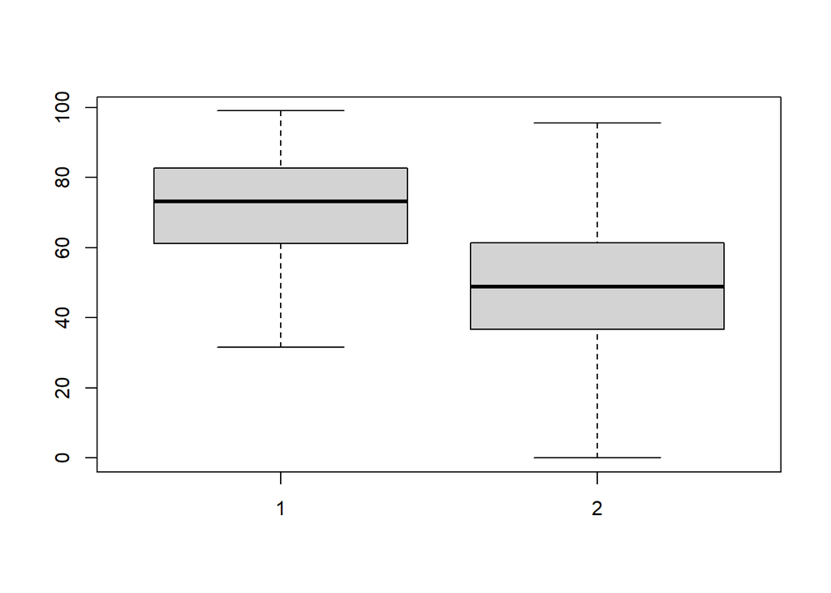

```r
gpaOAL <- dFile$GPA[1:451]
gpaYEAL <- dFile$GPA[452:902]

boxplot(gpaOAL,gpaYEAL)
```

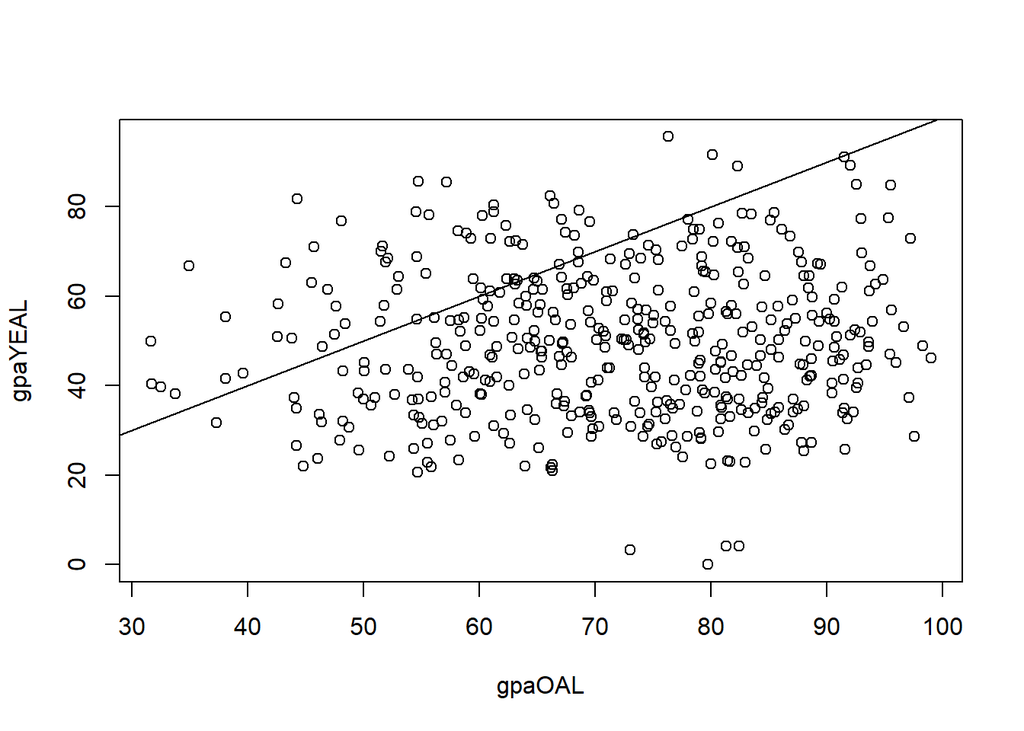

```r
plot(gpaOAL, gpaYEAL, abline(a=0, b=1))
```

```r
#H0: Mean difference in SBP is 0
# two-sided test

t.test(gpaOAL, gpaYEAL, mu=0, alt="two.sided", paired = T, conf = 0.99)
```

```
##
##  Paired t-test
##
## data:  gpaOAL and gpaYEAL
## t = 22.238, df = 450, p-value < 2.2e-16
## alternative hypothesis: true mean difference is not equal to 0
## 99 percent confidence interval:
##  19.69537 24.88055
## sample estimates:
## mean difference
##        22.28796
```

1. Aim In words, what is your objective here?

**To compare the difference between two selected groups in the same population**

2. Hypothesis and level of significance: Write your hypothesis in scientific form and determine the level of significance.

**H0: mu = 0, H1: mu != 0, alpha = 0.01**

3. Assumption Check: Tell why you use the paired t test, and Check the required assumptions. “comment on each of them is a must!”.

**The variables are metric and the difference of the paired values is normally distributed**

4. Result: Give the output of the test and write down the result (ex: since p value is less than alpha, I reject the null hypothesis).

**Since p value is less than alpha, I reject the null hypothesis**

5. Conclusion: You got your result in item d. Write down the conclusion of your result, in such a way that, the reader who doesn’t know any statistics can understand your findings.

## 9. (2p every item) Fisher’s exact test for count data

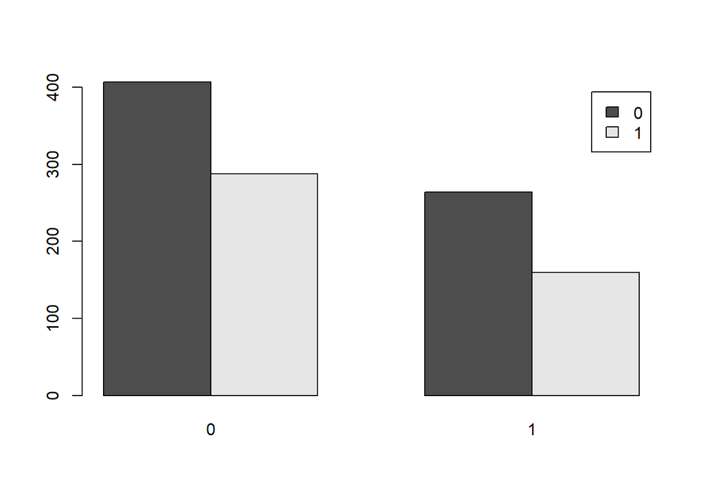

```r
TAB = table(dFile$GENDER,dFile$MAF_PS)

barplot(TAB,beside = T, legend = T)
```

```r
TESTFISHER = fisher.test(TAB, conf.int = T, conf.level = 0.99)
TESTFISHER
```

```
##
##  Fisher's Exact Test for Count Data
##
## data:  TAB
## p-value = 0.2324
## alternative hypothesis: true odds ratio is not equal to 1
## 99 percent confidence interval:
##  0.6130235 1.1940759
## sample estimates:
## odds ratio
##  0.8566012
```

1. Aim  
   In words, what is your objective here?

**We applied this test to compare gender and parents whose parents were primary school graduates.**

2. Hypothesis and level of significance: Write your hypothesis in scientific form and determine the level of significance.

3. Result:  
   Give the output of the test and write down the result (since p value is less than alpha, I reject the null hypothesis).

4. Conclusion:  
   You got your result in item c. Write down the conclusion of your result, in such a way that, the reader who doesn’t know any statistics can understand your findings.

**We can say that the status of parents being primary school graduates has the same effect on gender groups.**

5. Odds Ratio:  
   Comment about the odds ratio, what does it indicate?

**Odds ratio shows us the relationship between the probability of a situation occurring and the probability of it not happening. The calculation is quite simple, the probability of occurrence of the curious situation is divided by the probability of not happening. Odds ratio (0.8566012) tells us that; The effect of gender on parents being primary school graduates is 0.86 times.**